[figure not shown]

# Princeton Alumni Angels Startup Pipeline Data Analysis 2018 - Summer 2021

This is a simple data analysis using Python in a Jupyter Notebook of all the startups that have applied to Princeton Alumni Angels before summer of 2021. The goal of this analysis is to get a rough understanding of where PAA is standing in terms of its goal to invest in world class startups that have diverse leadership.

There is a particular focus on commenting about the diversity of the teams of startups that have applied to PAA. The data outputs also include specific years and PAA's portfolio for comparison.

We hope this data analysis provides a good benchmark for PAA in the future when even more startups have applied. Datasets are currently kept private to Princeton Alumni Angels, but that may change in the future. If you have any suggestions on how to improve our code/visuals or have anything you want us to add or explore, let us know as well!

Leon Chen '23 (leonchen@princeton.edu), Asher Joy '23 (asherj@princeton.edu)

**At the top of the page, there is a toggle labeled "show code". If you would like to see the code that we used to produce the graphs/statistics, just hit that button.**

## Summary

**1)** Applications to PAA have grown in number every year since forming in 2018, even through 2020. 2021 numbers will be calculated after applications close this year.

Link to Visuals and Code

**2)** The majority of startups that have applied to PAA have a Princeton connection. In addition, the majority of startups in PAA's portfolio also have a Princeton connection. PAA seems to be making full use of its network.

Link to Visuals and Code

**3)** The majority of startups that have applied to PAA indicate that they hear about PAA from the organization itself. The same follows PAA's portfolio. This is followed closesly by other alumni.

Link to Visuals and Code

**4)** Startups that have applied to PAA are very diverse in the industry that they serve. Healthcare is the dominant industry in startups that apply to PAA and is also the most common industry among PAA's portfolio.

Link to Visuals and Code

**5)** The majority of startups that have applied to PAA since 2020 have at least one male on their founding team.

Almost half of all startups that have applied to PAA since 2020 have **at least one female** on their founding team. We compared this statistic to the broader gender statistic in the startup landscape. It seems that PAA attracts more startups with diverse teams in terms of gender, but it's still too early to tell.

These statistics are very closely mimicked by PAA's portfolio.

PAA should still work towards encouraging more startups with diverse founding teams (and teams in general) to apply.

Link To Visuals and Code

**6)** The majority of startups that have applied to PAA since 2020 have at least one member on their founding team that identifies as White. This is followed closely by Asian.

On the other hand, a minority of startups have at least one member on their founding team that identifies as Black, Hispanic/Latinx, or other races/ethnicities.

These statistics are very closely mimicked by PAA's portfolio.

In terms of race/ethnicity, PAA can definitely do better in encouraging more diverse startups to apply.

Link To Visuals and Code

**7)** There are very few startups that have applied to PAA since 2020 that have at least one founding member that identifies as LGBTQ+. There are no startups in PAA's portfolio that have at least one founding member that identifies as LGBTQ+.

It should be noted that there was no dedicated section in the application asking for LGBTQ+ connections - the analysis we have performed here is largely inconclusive.

Link to Visuals and Code

**8)** There are some startups that have applied to PAA since 2020 that have at least one founding member that has served in active duty. There are also some startups in PAA's portfolio that have at least one founding member that has served in active duty.

Link to Visuals and Code

**9)** New York and California are the most popular headquarters locations for startups that have applied to PAA. This is most likely due to the fact that PAA is based in these two states, so networking and marketing is easier.

This characteristic is closesly mimicked by PAA's portfolio.

Perhaps PAA should think about where to market better to get the maximum outreach possible (e.g. Chicago).

Link to Visuals and Code

## Important stuff needed to code

```python
import pandas as pd
import numpy as np
from collections import Counter
import matplotlib.pyplot as plt
plt.style.use("fivethirtyeight")
import matplotlib.ticker as mtick
import panel as pn
from IPython.display import IFrame, HTML
```

```python
all_data = pd.read_csv("PAA_Data - Jupyter.csv")
portfolio_data = pd.read_csv("PAA_Investor_Company_Data - Jupyter.csv")
data_clean = []
data_clean.extend((all_data, portfolio_data))
#all_data.head()
```

```python
def clean_list(data):
    clean_list = []
    for i in range(len(data)):
        ix = data.iloc[i]
        ix = ix.split(',')
        array = []
        for i in ix:
            i = i.strip()
            array.append(i)
        clean_list.append(array)
    return clean_list

#Make these column names a little bit more legible
for i in range(len(data_clean)):
    data_clean[i].rename(columns={"Industry Served (organized)": "Industry", "Amount Already Closed of the Total Currently Raising":
                        "Already Closed", "[Gender] Does anyone on your founding team identify as:" : "Gender",
                        "[Race/Ethnicity] Does anyone on your founding team identify as:": "Race/Ethnicity",
                        "Has anyone on your founding team ever served on active duty?": "Active Duty", "Princeton Connection? (Binary)" :
                       "Princeton Connection", "How did you hear about Princeton Alumni Angels?" : "Hear", "LGBTQ? (Binary)" : "LGBTQ"},
                        inplace = True)

    data_clean[i]["Gender"] = data_clean[i]["Gender"].fillna("")
    data_clean[i]["Race/Ethnicity"] = data_clean[i]["Race/Ethnicity"].fillna("")
    data_clean[i]["Active Duty"] = data_clean[i]["Active Duty"].fillna("")
    data_clean[i]["State Headquartered"] = data_clean[i]["State Headquartered"].fillna("")
    data_clean[i]["Hear"] = data_clean[i]["Hear"].fillna("")
    data_clean[i]["LGBTQ"] = data_clean[i]["LGBTQ"].fillna("")

    data_clean[i]["Gender"] = clean_list(data_clean[i]["Gender"])
    data_clean[i]["Race/Ethnicity"] = clean_list(data_clean[i]["Race/Ethnicity"])
    data_clean[i]["Hear"] = clean_list(data_clean[i]["Hear"])
```

```python
first_2018 = all_data["Pitch Year"].searchsorted(2018, side='left')
first_2019 = all_data["Pitch Year"].searchsorted(2019, side = 'left')
first_2020 = all_data["Pitch Year"].searchsorted(2020, side = 'left')
first_2021 = all_data["Pitch Year"].searchsorted(2021, side='left')

data_2018 = all_data.iloc[first_2018:first_2019]
data_2019 = all_data.iloc[first_2019:first_2020]
data_2020 = all_data.iloc[first_2020:first_2021]
#data_2021 = all_data.iloc[first_2021:]

data = []
data.extend((all_data, data_2018, data_2019, data_2020, portfolio_data))
```

```python
princeton_orange = "#f58025"

def counter(copy):
    values = copy.values
    c = Counter()
    for vals in values:
        for x in vals:
            c[x] += 1
    return c

def sort(cats, vals):
    vals1 = []
    cats1 = []
    sorted_in = np.argsort(vals)
    for i in range(len(sorted_in)):
        vals1.append(vals[sorted_in[-(i+1)]])
        cats1.append(cats[sorted_in[-(i+1)]])
    return cats1, vals1

def add_counter(counter):
    cats = []
    vals = []
    for i in counter:
        cats.append(i)
        vals.append(counter[i])
    return cats, vals

def percent_single_selec(data):
    array = []
    copy = data.copy()
    for i in range(len(data)):
        array.append(100*data[i]/sum(copy))
    return array

def percent_multiple_selec(vals, length):
    percent = []
    for i in range(len(vals)):
        percent.append(100*vals[i] / length)
    return percent

def main_graph(cats, vals, percents, label):
    graph = plt.barh(cats, vals, color = princeton_orange)
    plt.xlabel('Number of Startups')
    plt.ylabel(label)
    plt.gca().spines["bottom"].set_color("black")
    plt.gca().invert_yaxis()
    plt.grid(False)
    i = 0
    for p in graph:
        height = p.get_height()
        width = p.get_width()
        plt.text(x= width + vals[0]/20, y = p.get_y() + height / 2,
            s="{:.3f}%".format(percents[i]),
            ha='center')
        i += 1
```

## Applications have grown in number every year since PAA was formed

Let's take a look at the number of applications PAA has received throughout the years and see if the group is expanding its network of startups and investors.

We leave out the current year 2021 since there are still pitch cycles coming up.

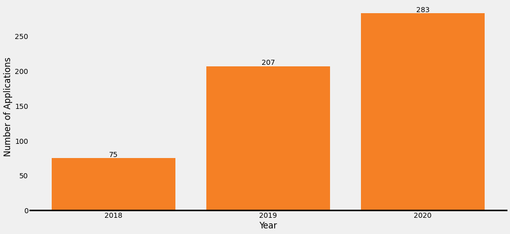

```
Percent change from 2018 to 2019:  176.000%
Percent change from 2019 to 2020:  36.715%
```

```python
counts = all_data["Pitch Year"].iloc[:first_2021].value_counts()

plt.figure(figsize = (15, 7))
graph = plt.bar(counts.index, counts.values, color = princeton_orange)

for p in graph:
    height = p.get_height()
    plt.text(x=p.get_x() + p.get_width() / 2, y=height + 2,
        s=height,
        ha='center')

plt.xlabel("Year")
plt.ylabel("Number of Applications")
plt.locator_params(axis="both", integer=True, tight=True)
plt.grid(False)
plt.gca().spines['bottom'].set_color('black')
plt.show()

percent18_19 = (counts[2019] - counts[2018])/counts[2018]
percent19_20 = (counts[2020] - counts[2019])/counts[2019]

print("Percent change from 2018 to 2019: ", '{:.3%}'.format(percent18_19))
print("Percent change from 2019 to 2020: ", '{:.3%}'.format(percent19_20))
```

The explosive growth from 2018 to 2019 (176% !!!) can most likely be attributed to the fact that applications in 2018 only opened up late summer, resulting in fewer application numbers for the entire year and thus a huge percent increase when comparing 2019 application numbers.

2020 seemed to still be a solid application year even facing the pandemic, with a 36.715% increase in applications from 2019.

2021 numbers will be calculated after applications close for this year.

Go Back to Summary

## The majority of startups that have applied to PAA have a Princeton connection. The same follows for PAA's portfolio

PAA encourages Princeton connected startups to apply and invest in them. Startups had the option to list their Princeton connection in their application, and we converted this to binary Yes/No data for easier use.

Let's calculate the statistic for startups and whether or not they are Princeton connected, filtered by year and portfolio:

```python
all_counts, all_percents, mpl_pane = [], [], []
for i in range(len(data)):
    all_counts.append(data[i]["Princeton Connection"].value_counts())

    all_percents.append(percent_single_selec(all_counts[i]))

    fig = plt.figure(figsize = (13, 6))
    main_graph(all_counts[i].index, all_counts[i].values, all_percents[i], "Princeton Connection?")
    plt.close(fig)
    mpl_pane.append(pn.pane.Matplotlib(fig, dpi=144, tight = True))

tabs = pn.Tabs(("All", mpl_pane[0]), ("2018", mpl_pane[1]),
               ("2019", mpl_pane[2]), ("2020", mpl_pane[3]),
                ("Portfolio", mpl_pane[4]))

#tabs.save("visuals/tabs1.html")
IFrame(src='visuals/tabs1.html', width=970, height=500)
#IFrame(src='2018-2021/visuals/tabs1.html', width=970, height=500)
```

[interactive chart not shown]

**72.861%** of startups that have applied to PAA have a Princeton connection.

**77.419%** of startups invested in by PAA have a Princeton connection.

Looks like PAA is doing a great job utilizing its network in encouranging Princeton connection startups to apply!

Go Back to Summary

## The majority of startups hear about PAA from the organization itself. The same follows for PAA's portfolio

The startup application includes a question asking where the applying startup heard about PAA. The startup is able to indicate multiple options for sources (for example, a startup can indicate that they heard about PAA from both Princeton alumni and the Princeton Entrepreneurship Council).

The graphs below show the **top 5** sources for how startups heard about PAA, filtered by year and portfolio:

```python
def label_fit(cats):
    for i in range(len(cats)):
        if cats[i] == "Princeton Entrepreneurship Council (PEC) / Alumni Entrepreneurs Fund":
            cats[i] = "Princeton Entrepreneurship Council (PEC) / \n Alumni Entrepreneurs Fund"

all_counters, all_categories, all_values, sorted_categories, sorted_values, all_percents, mpl_pane = [], [], [], [], [], [], []
for i in range(len(data)):
    all_counters.append(counter(data[i]["Hear"]))

    all_categories.append(add_counter(all_counters[i])[0])
    all_values.append(add_counter(all_counters[i])[1])

    sorted_categories.append(sort(all_categories[i], all_values[i])[0])
    sorted_values.append(sort(all_categories[i], all_values[i])[1])

    sorted_categories[i] = sorted_categories[i][:5]
    sorted_values[i] = sorted_values[i][:5]

    label_fit(sorted_categories[i])

    all_percents.append(percent_multiple_selec(sorted_values[i], len(data[i])))

    fig = plt.figure(figsize = (13, 6))
    main_graph(sorted_categories[i], sorted_values[i], all_percents[i], "Source")
    plt.close(fig)
    mpl_pane.append(pn.pane.Matplotlib(fig, dpi=144, tight = True))


tabs = pn.Tabs(("All", mpl_pane[0]), ("2018", mpl_pane[1]), ("2019", mpl_pane[2]),
               ("2020", mpl_pane[3]), ("Portfolio", mpl_pane[4]))
#tabs.save("visuals/tabs2.html")
IFrame(src='visuals/tabs2.html', width=955, height=500)
#IFrame(src='2018-2021/visuals/tabs2.html', width=955, height=500)
```

[interactive chart not shown]

The majority of startups hear about PAA from the organization itself, followed closely by other Princeton alumni. Seems like PAA is making full use of its network!

Go Back to Summary

## Startups that have applied to PAA are generally varied in industry served, but Healthcare is the most prominent across the board; sector-focused marketing also seems apparent (due to pitch cycles)

Startups that have applied to PAA indicate what type of industry they serve. It's worthy to note that PAA has different focuses for each pitch cycle, and these focuses may show up on our visuals/counts (e.g. Healthcare focused pitch cycle).

The graphs below show the **10 most common industries** startups are involved in, filtered by year and portfolio:

```python
all_counts, all_percents, mpl_pane = [], [], []
for i in range(len(data)):
    all_counts.append(data[i]["Industry"].value_counts())

    all_percents.append(percent_single_selec(all_counts[i]))
    all_counts[i] = all_counts[i][:10]
    all_percents[i] = all_percents[i][:10]

    fig = plt.figure(figsize = (13, 8))
    main_graph(all_counts[i].index, all_counts[i].values, all_percents[i], "Industry")
    plt.close(fig)
    mpl_pane.append(pn.pane.Matplotlib(fig, dpi=144, tight = True))

tabs = pn.Tabs(("All", mpl_pane[0]), ("2018", mpl_pane[1]),
               ("2019", mpl_pane[2]), ("2020", mpl_pane[3]),
              ("Portfolio", mpl_pane[4]))
#tabs.save("visuals/tabs3.html")
IFrame(src='visuals/tabs3.html', width=970, height=635)
#IFrame(src='2018-2021/visuals/tabs3.html', width=970, height=635)
```

[interactive chart not shown]

Notice that there is a particular focus for startups to be involved in the Healthcare Technologies industry, although this may reflect PAA's recent healthcare-focused pitch cycle. FinTech follows behind, and it's worthy to note that many startups that apply to PAA still indicate "Other" for their industry.

Go Back to Summary

## Since 2020, the majority of startups that have applied to PAA indicate that someone on their founding team identifies as male (e.g. founder, co-founder). The same follows for PAA's portfolio

At the beginning of 2020, the application form that startups had to fill out in order to apply to PAA started inncluding the following question in relation to gender and sexuality: **"Does anyone on your founding team identify as (select all that apply):**.

Options included Male, Female, Non-Binary/Third Gender, Prefer not to say, and a "fill in your blank" answer (which peculiarly, all the groups that chose this option answered "Human being").

The graphs below show the number of startups that have **at least one team member that identifies as the respective categories**, with the percentage of startups next to the bars.

Note that startups can have multiple founders - this is why the percentages don't add up to $100$%. They should be read as **X% of startups have at least one founding team member that indentifies as *CATEGORY***.

```python
def first_gender(data):
    for i in range(len(data)):
        if all('' == value for value in data.iloc[i]):
            pass
        else:
            return i
def prefer(data):
    for i in range(len(data)):
        if '' in data.iloc[i]:
            data.iloc[i] = ["Prefer Not to Say"]

first_gender_all=0
first_gender_portfolio=0

first_gender_all = first_gender(all_data["Gender"])
first_gender_portfolio = first_gender(portfolio_data["Gender"])

gender_data = []
gender_data.extend((all_data["Gender"].iloc[first_gender_all:], portfolio_data["Gender"].iloc[first_gender_portfolio:]))

all_counters, all_categories, all_values, sorted_categories, sorted_values, all_percents, mpl_pane = [], [], [], [], [], [], []
for i in range(len(gender_data)):
    prefer(gender_data[i])

    all_counters.append(counter(gender_data[i]))

    all_categories.append(add_counter(all_counters[i])[0])
    all_values.append(add_counter(all_counters[i])[1])

    sorted_categories.append(sort(all_categories[i], all_values[i])[0])
    sorted_values.append(sort(all_categories[i], all_values[i])[1])

    all_percents.append(percent_multiple_selec(sorted_values[i], len(gender_data[i])))

    fig = plt.figure(figsize = (13, 6))
    main_graph(sorted_categories[i], sorted_values[i], all_percents[i], "Gender")
    plt.close(fig)
    mpl_pane.append(pn.pane.Matplotlib(fig, dpi=144, tight = True))

#tabs = pn.Tabs(("All", mpl_pane[0]), ("Portfolio", mpl_pane[1]))
#tabs.save("visuals/tabs4.html")
IFrame(src='visuals/tabs4.html', width=955, height=490)
#IFrame(src='2018-2021/visuals/tabs4.html', width=955, height=490)
```

[interactive chart not shown]

Hmm...the majority of startups that have applied to PAA since 2020 indicate that there is at least one male on their founding team. Perhaps this doesn't tell the whole picture. What we should probably focus on more is comparing the amount/precentage of startups that have at least one female on their founding team to the amount/percentage that have **no female** on their founding team.

The Silicon Valley Bank (SVB) is a bank that assists in funding startups. In 2020, they released their Startup Outlook Report that includes statistics regarding a diverse range of topics including gender. They demonstrated through their surveys that **only 32% of startups had at least one (1) female founder**.$^{2}$

Here's their graphic that includes the founder gender statistic at the bottom:

[figure not shown]

The calculated percentage of startups that have applied to PAA that have at least one female member on their founding team is **42.494%**.

For startups invested in by PAA, this percentage is **41.935%**.

Both of these numbers are grater than the **32%** of startups that have at least one female founder according to SVB. Does this mean that PAA is good at promoting and investing in startups with more diverse teams to apply?

It's worth reiterating that this data was **only introduced at the beginning of 2020**. One year of data is not enough to determine whether or not PAA successfully encourages startups with female founders to apply, even if the application pipeline shows this statistic to be higher than the overall market distribution of startups that have at least one female founder.

We hope that starting the analysis now will serve as a benchmark for PAA (and potentially other angel groups!) to determine if the group is advocating enough for diverse leadership.

Go Back to Summary

## Since 2020, the majority of startups that have applied to PAA indicate that someone on their founding team identifies as White (e.g. founder, co-founder). The same follows for PAA's portfolio

At the beginning of 2020, another question was introduced to the application in regards to race/ethnicity: **"Does anyone on your founding team identify as (select all that apply):**.

The question had a range of possible selections including White, Asian, African-American/Black, Hispanic/Latinx and other answers, including one to specify one not listed.

The graphs below show the number of startups that have **at least one team member that identifies as the respective categories**, with the percentage of startups next to the bars.

Note that startups can have multiple founders - this is why the percentages don't add up to $100$%. They should be read as **X% of startups have at least one founding team member that indentifies as *CATEGORY***.

```python
#Now for Race/Ethnicity
def white_space_func(copy):
    for i in range(len(copy)):
        if '' in copy.iloc[i]:
            copy.iloc[i] = ["No Response"]

def asian_func(copy):
    for i in range(len(copy)):
        j = 0
        for string in copy.iloc[i]:
            if "Asian" in string:
                if j > 0:
                    copy.iloc[i].remove(string)
                else:
                    index = copy.iloc[i].index(string)
                    copy.iloc[i][index] = "Asian"
                    j += 1

first_re_all = first_gender_all
first_re_portfolio = first_gender(portfolio_data["Race/Ethnicity"])

race_data = []
race_data.extend((all_data["Race/Ethnicity"].iloc[first_re_all:], portfolio_data["Race/Ethnicity"].iloc[first_re_portfolio:]))

all_counters, all_categories, all_values, sorted_categories, sorted_values, all_percents, mpl_pane = [], [], [], [], [], [], []
for i in range(len(race_data)):
    white_space_func(race_data[i])
    asian_func(race_data[i])

    all_counters.append(counter(race_data[i]))

    all_categories.append(add_counter(all_counters[i])[0])
    all_values.append(add_counter(all_counters[i])[1])

    sorted_categories.append(sort(all_categories[i], all_values[i])[0])
    sorted_values.append(sort(all_categories[i], all_values[i])[1])

    all_percents.append(percent_multiple_selec(sorted_values[i], len(race_data[i])))

    sorted_categories[i] = sorted_categories[i][:6]
    sorted_values[i] = sorted_values[i][:6]
    all_percents[i] = all_percents[i][:6]

    fig = plt.figure(figsize = (13, 6))
    main_graph(sorted_categories[i], sorted_values[i], all_percents[i], "Race/Ethnicity")
    plt.close(fig)
    mpl_pane.append(pn.pane.Matplotlib(fig, dpi=144, tight = True))

tabs = pn.Tabs(("All", mpl_pane[0]), ("Portfolio", mpl_pane[1]))
#tabs.save("visuals/tabs5.html")
IFrame(src='visuals/tabs5.html', width=955, height=490)
#IFrame(src='2018-2021/visuals/tabs5.html', width=955, height=490)
```

[interactive chart not shown]

It's not entirely unexpected that a majority of startups that have applied to PAA have someone on their founding team that identifies as White. It also isn't unexpected that the percentage of startups that have someone on their founding team that identifies as Asian follows closely at second.

The Kauffman Fellows Program reports that White and Asian executives in startups are drastically over-represented compared to the working-age US population, while Latinx and Black executives are drastically under-represented.$^{3}$

Here's their graphic:

[figure not shown]

It's extremely worth mentioning that the same Kauffman study also found that although more diverse teams generally have more limited access to capital, when these teams are able to get funding, **they raise more capital during all rounds of funding** and **have higher future returns**.$^{4}$

Here are their graphics:

[figure not shown]

PAA already indicates on their website that the group aspires to invest in companies with diverse leadership. Perhaps, PAA should **actively encourage** these types of startups to apply and **actively invest in them** given these statistics!

We hope this analysis will serve as a benchmark for the future, especially given the data that diverse founding teams raise more money and generate higher returns in the future.

Go Back to Summary

## Since 2020, there are very few startups that have applied to PAA where at least one founding member identifies as part of the LGBTQ+ community. For startups in PAA's portfolio, there are none

At the beginning of 2020, startups also had the option to indicate whether or not they had members that identified as LGBTQ+ by utilizing the "other" option in the "Gender" section of the application. We converted this to binary Yes/No data by looking for key LGBTQ+ words.

Unfortunately, this detracts from the accuracy of the LGBTQ statistics we calculated as there was no separate question asking for LGBTQ+. We leave the statistics and visuals in to serve as a benchmark in the future:

```python
race_data = []
race_data.extend((all_data["LGBTQ"].iloc[first_gender_all:], portfolio_data["LGBTQ"].iloc[first_gender_portfolio:]))
all_counts, all_percents, mpl_pane = [], [], []
for i in range(len(race_data)):
    all_counts.append(race_data[i].value_counts())

    all_percents.append(percent_single_selec(all_counts[i]))

    fig = plt.figure(figsize = (13, 6))
    main_graph(all_counts[i].index, all_counts[i].values, all_percents[i], "LGBTQ?")
    plt.close(fig)
    mpl_pane.append(pn.pane.Matplotlib(fig, dpi=144, tight = True))

tabs = pn.Tabs(("All", mpl_pane[0]), ("Portfolio", mpl_pane[1]))

#tabs.save("visuals/tabs6.html")
IFrame(src='visuals/tabs6.html', width=970, height=500)
#IFrame(src='2018-2021/visuals/tabs6.html', width=970, height=500)
```

[interactive chart not shown]

Looks like **0.254%** of startups that have applied to PAA since 2020 have at least one founding member that identifies as LGBTQ+.

For startups invested in by PAA, this percentage is **0%**.

Go Back to Summary

## Since 2020, there have been a few startups that have applied to PAA where at least one member on their founding team has served on active duty. The same follows for PAA's portfolio

At the beginning of 2020, another question was introduced to the application in regards to active duty: **Has anyone on your founding team ever served on active duty?**. We treat a non-response as a "not applicable" answer.

Let's calculate the statistics below:

```python
def not_applicable(copy):
    for i in range(len(copy)):
        if copy.iloc[i] == "":
            copy.iloc[i] = "Not applicable"

first_active_all = first_re_all
first_active_portfolio = first_gender(portfolio_data["Active Duty"])

race_data = []
race_data.extend((all_data["Active Duty"].iloc[first_active_all:], portfolio_data["Active Duty"].iloc[first_active_portfolio:]))
all_counts, all_percents, mpl_pane = [], [], []
for i in range(len(race_data)):
    not_applicable(race_data[i])
    all_counts.append(race_data[i].value_counts())

    all_percents.append(percent_single_selec(all_counts[i]))

    fig = plt.figure(figsize = (13, 6))
    main_graph(all_counts[i].index, all_counts[i].values, all_percents[i], "Active Duty?")
    plt.close(fig)
    mpl_pane.append(pn.pane.Matplotlib(fig, dpi=144, tight = True))

tabs = pn.Tabs(("All", mpl_pane[0]), ("Portfolio", mpl_pane[1]))
#tabs.save("visuals/tabs7.html")
IFrame(src='visuals/tabs7.html', width=955, height=490)
#IFrame(src='2018-2021/visuals/tabs7.html', width=955, height=490)
```

[interactive chart not shown]

Looks like **9.16%** of startups that have applied to PAA since 2020 have at least one founding member that has served in active duty.

For startups invested in by PAA, this percentage is **10.526%**.

Go Back to Summary

## Startups that have applied to PAA often headquarter on the coasts, specifically in New York and California. The same follows for PAA's portfolio

Startups that apply to PAA indicate where they are registered and located. Let's calculate some basic statistics on where startups are located. We have omitted registration location since it doesn't give us relevant information, as headquarter location is more telling. If you're curious, Delaware is the most common registration location for startups that have applied to PAA (and basically the startup industry as a whole) because of its favorable corporation laws.

The graphs below show the **10 most common headquarter locations** for startups, filtered by year and portfolio:

```python
all_counts = []
for i in range(len(data)):
    all_counts.append(data[i]["State Headquartered"].value_counts())

all_percents, mpl_pane = [], []
for i in range(len(all_counts)):
    all_percents.append(percent_single_selec(all_counts[i]))
    all_counts[i] = all_counts[i][:10]
    all_percents[i] = all_percents[i][:10]

    fig = plt.figure(figsize = (13, 7))
    main_graph(all_counts[i].index, all_counts[i].values, all_percents[i], "Location Headquartered")
    plt.close(fig)
    mpl_pane.append(pn.pane.Matplotlib(fig, tight = True))

tabs = pn.Tabs(("All", mpl_pane[0]), ("2018", mpl_pane[1]),
               ("2019", mpl_pane[2]), ("2020", mpl_pane[3]),
              ("Portfolio", mpl_pane[4]))
#tabs.save("visuals/tabs8.html")
IFrame(src='visuals/tabs8.html', width=960, height=570)
#IFrame(src='2018-2021/visuals/tabs8.html', width=960, height=570)
```

[interactive chart not shown]

The most common startup headquarter amongst those that have applied to PAA is **New York**, followed closely by **California**. This isn't entirely surprising especially considering PAA has chapters based primarily in these two states, so marketing is done more efficiently in these areas. The same can be said for statups invested in by PAA.

Below is an interactive map with **all the startups that have applied to PAA**. There have been startups headquartered internationally, but including them in the map would have expanded the scope of the visual too much. In the future, it may be worth including these international startups once numbers increase.

**There may be some locations that have duplicate startups - we left them in because PAA allows applications for different cycles, and startups may have had time to grow and change.**

```python
%%html
<iframe title="" aria-label="Map" id="datawrapper-chart-BDaMr" src="https://datawrapper.dwcdn.net/BDaMr/11/" scrolling="no" frameborder="0" style="width: 0; min-width: 100% !important; border: none;" height="530"></iframe><script type="text/javascript">!function(){"use strict";window.addEventListener("message",(function(e){if(void 0!==e.data["datawrapper-height"]){var t=document.querySelectorAll("iframe");for(var a in e.data["datawrapper-height"])for(var r=0;r<t.length;r++){if(t[r].contentWindow===e.source)t[r].style.height=e.data["datawrapper-height"][a]+"px"}}}))}();
</script>
```

[interactive chart not shown]

Below is an interactive map of **startups invested in by PAA**. Clicking on a marker will allow you to view the specific startups invested in by PAA from each specific state, along with their website and Linkedin page.

```python
%%html
<iframe title="" aria-label="Map" id="datawrapper-chart-WrdMQ" src="https://datawrapper.dwcdn.net/WrdMQ/4/" scrolling="no" frameborder="0" style="width: 0; min-width: 100% !important; border: none;" height="472"></iframe><script type="text/javascript">!function(){"use strict";window.addEventListener("message",(function(e){if(void 0!==e.data["datawrapper-height"]){var t=document.querySelectorAll("iframe");for(var a in e.data["datawrapper-height"])for(var r=0;r<t.length;r++){if(t[r].contentWindow===e.source)t[r].style.height=e.data["datawrapper-height"][a]+"px"}}}))}();
</script>
```

[interactive chart not shown]

Go Back to Summary

Thank you for taking the time to read this data analysis report. This is the first time that PAA has analyzed its startup pipeline and is something that the group believes to be extremely beneficial for the organization as a whole.

If you have any suggestions on how to improve this data analysis, please let us know. We hope to continue this project over the next few years.

## References and sources

$^{1}$ https://www.investopedia.com/articles/personal-finance/102015/series-b-c-funding-what-it-all-means-and-how-it-works.asp

$^{2}$ https://www.svb.com/globalassets/library/uploadedfiles/content/trends_and_insights/reports/startup_outlook_report/suo_global_report_2020-final.pdf

$^{3}$ https://www.kauffmanfellows.org/journal_posts/the-pipeline-myth-ethnicity-fund-managers

$^{4}$ https://www.kauffmanfellows.org/journal_posts/the-pipeline-myth-ethnicity-fund-managers

Go Back to Top of Page